# Ejercicio de regresion lineal simple

# Introduccion

En este ejemplo trabajaremos con el dataset Boston del paquete MASS. El objetivo del problema es predecir el valor de la vivienda en funcion de las variables del fichero.

**Objetivo:** En este ejercicio vamos a comenzar con un modelo de regresion simple por lo que analizaremos la relacion entre la variable *lstat* con *medv*.

Este dataset Boston recoge la media del valor de la vivienda en 506 areas residenciales de Boston. Junto con el precio, se han registrado 13 variables adicionales.

- crim: ratio de criminalidad per capita de cada ciudad.
- zn: Proporcion de zonas residenciales con edificaciones de mas de 25.000 pies cuadrados.
- indus: proporcion de zona industrializada.
- chas: Si hay rio en la ciudad (= 1 si hay rio; 0 no hay).
- nox: Concentracion de oxidos de nitrogeno (partes per 10 millon).
- rm: promedio de habitaciones por vivienda.
- age: Proporcion de viviendas ocupadas por el propietario construidas antes de 1940.
- dis: Media ponderada de la distancias a cinco centros de empleo de Boston.
- rad: Indice de accesibilidad a las autopistas radiales.
- tax: Tasa de impuesto a la propiedad en unidades de $10,000.
- ptratio: ratio de alumnos/profesor por ciudad.
- black: 1000(Bk - 0.63)^2 donde Bk es la proporcion de gente de color por ciudad.
- lstat: porcentaje de poblacion en condicion de pobreza.
- medv: Valor medio de las casas ocupadas por el dueno en unidades de $1000s.

Primero comenzaremos por cargar los paquetes necesarios.

```r
library(MASS)
library(ISLR)
library(psych)
library(caret)
library (ggplot2)
library(DMwR)  # para usar la funcion regr.eval
```

A continuacion, cargamos el dataset y visualizamos sus primeros elementos. tambien identificamos el numero de filas y columnas.

```r
# Carga el dataset
data("Boston")
# Muestra informacion del data set
?Boston
# Muestra las primeras filas del dataset
head (Boston)
```

|  | crim | zn | indus | chas | nox | rm | age | dis | rad | tax | ptratio | black | lstat | medv |
| --- | --- | --- | --- | --- | --- | --- | --- | --- | --- | --- | --- | --- | --- | --- |
| 1 | 0.00632 | 18 | 2.31 | 0 | 0.538 | 6.575 | 65.2 | 4.0900 | 1 | 296 | 15.3 | 396.90 | 4.98 | 24.0 |
| 2 | 0.02731 | 0 | 7.07 | 0 | 0.469 | 6.421 | 78.9 | 4.9671 | 2 | 242 | 17.8 | 396.90 | 9.14 | 21.6 |
| 3 | 0.02729 | 0 | 7.07 | 0 | 0.469 | 7.185 | 61.1 | 4.9671 | 2 | 242 | 17.8 | 392.83 | 4.03 | 34.7 |
| 4 | 0.03237 | 0 | 2.18 | 0 | 0.458 | 6.998 | 45.8 | 6.0622 | 3 | 222 | 18.7 | 394.63 | 2.94 | 33.4 |
| 5 | 0.06905 | 0 | 2.18 | 0 | 0.458 | 7.147 | 54.2 | 6.0622 | 3 | 222 | 18.7 | 396.90 | 5.33 | 36.2 |
| 6 | 0.02985 | 0 | 2.18 | 0 | 0.458 | 6.430 | 58.7 | 6.0622 | 3 | 222 | 18.7 | 394.12 | 5.21 | 28.7 |

```r
# numero de filas y columnas
nrow(Boston)
```

```
[1] 506
```

```r
ncol(Boston)
```

```
[1] 14
```

# Analisis exploratorio

En primer lugar se realiza un analisis basico de los datos de forma numerica y grafica. Usaremos la funcion **summary** que cuando se aplica a una variable presenta un pequeno resumen descriptivo. Si la variable es numerica, dicho resumen incluye el manimo, maximo, mediana, primer y tercer cuartiles, media y numero de valores perdidos. Si la variable es de tipo factor, **summary()** muestra el numero de observaciones en cada nivel del factor:

```r
summary(Boston)
```

```
      crim                zn             indus            chas              nox
 Min.   : 0.00632   Min.   :  0.00   Min.   : 0.46   Min.   :0.00000   Min.   :0.3850
 1st Qu.: 0.08204   1st Qu.:  0.00   1st Qu.: 5.19   1st Qu.:0.00000   1st Qu.:0.4490
 Median : 0.25651   Median :  0.00   Median : 9.69   Median :0.00000   Median :0.5380
 Mean   : 3.61352   Mean   : 11.36   Mean   :11.14   Mean   :0.06917   Mean   :0.5547
 3rd Qu.: 3.67708   3rd Qu.: 12.50   3rd Qu.:18.10   3rd Qu.:0.00000   3rd Qu.:0.6240
 Max.   :88.97620   Max.   :100.00   Max.   :27.74   Max.   :1.00000   Max.   :0.8710
       rm             age              dis              rad              tax           ptratio
 Min.   :3.561   Min.   :  2.90   Min.   : 1.130   Min.   : 1.000   Min.   :187.0   Min.   :12.60
 1st Qu.:5.886   1st Qu.: 45.02   1st Qu.: 2.100   1st Qu.: 4.000   1st Qu.:279.0   1st Qu.:17.40
 Median :6.208   Median : 77.50   Median : 3.207   Median : 5.000   Median :330.0   Median :19.05
 Mean   :6.285   Mean   : 68.57   Mean   : 3.795   Mean   : 9.549   Mean   :408.2   Mean   :18.46
 3rd Qu.:6.623   3rd Qu.: 94.08   3rd Qu.: 5.188   3rd Qu.:24.000   3rd Qu.:666.0   3rd Qu.:20.20
 Max.   :8.780   Max.   :100.00   Max.   :12.127   Max.   :24.000   Max.   :711.0   Max.   :22.00
     black            lstat            medv
 Min.   :  0.32   Min.   : 1.73   Min.   : 5.00
 1st Qu.:375.38   1st Qu.: 6.95   1st Qu.:17.02
 Median :391.44   Median :11.36   Median :21.20
 Mean   :356.67   Mean   :12.65   Mean   :22.53
 3rd Qu.:396.23   3rd Qu.:16.95   3rd Qu.:25.00
 Max.   :396.90   Max.   :37.97   Max.   :50.00
```

Tambien comprobaremos que no existen valores ausentes (NA) con la funcion **any(is.na(dataset))**.

```r
# Podemos contar los elementos ausentes
any(is.na(Boston))
```

```
[1] FALSE
```

## Distribucion normal

Antes de generar el modelo, representaremos los datos para cuantificar la posible relación lineal entre variables y su magnitud. Si no detectáramos esta relación pasaríamos a plantearnos métodos de ajuste alternativos. Graficaremos para tratar de ver la relacion entre la variable resultado y las caracteristicas.

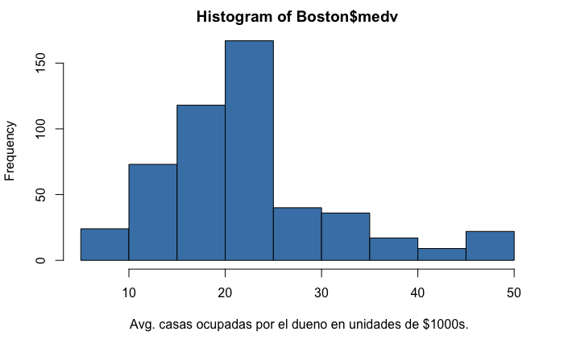

```r
#Dibujar un histograma. El argumento freq determina el tipo de histograma.
#freq = TRUE indica la frecuencia absoluta (conteo) en el eje y (es el valor por defecto).
#freq = FALSE indica la densidad
hist(Boston$medv, xlab=" Avg. casas ocupadas por el dueno en unidades de $1000s.", ylab="Frequency", col="steelblue")
```

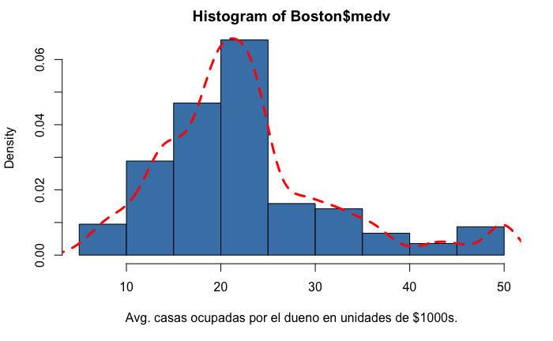

```r
#DIBUJAR histograma con funcion de densidad.

hist(Boston$medv, xlab="Avg. casas ocupadas por el dueno en unidades de $1000s.", ylab="Density", col="steelblue", freq=FALSE)
lines(density(Boston$medv),col="red", lty=2, lwd=3 )
```

Hacer la misma representación utilizando ggplot2:

```r
data <- data.frame(Boston$medv)
View(data)
ggplot(Boston, aes(x = as.factor(medv), y = density(medv))) + geom_histogram() + geom_curve()
```

[output not shown]

## Correlación y multicolinealidad

Ahora, vamos a crear la matriz de correlacion que mide la fuerza y la direccion de las relaciones entre las variables. Los valores que puede tomar siempre se encuentran comprendidos entre +1 o -1.

- Cuando r = -1, existe una relacion lineal perfecta negativa.
- Si r esta proximo a -1, existe una relacion lineal negativa muy fuerte.
- Cuando r esta proximo a 0, significa que no hay una relacion lineal.
- Si r esta proximo a +1, existe una relacion lineal positiva muy fuerte.
- Cuando r = +1, existe una relacion lineal perfecta positiva.

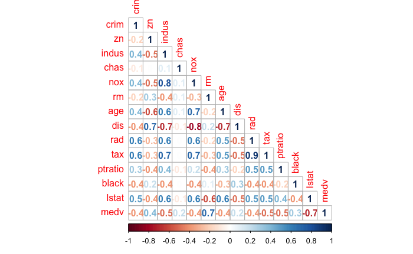

**Observaciones:**

- Para aplicar el modelo de regresion lineal, seleccionaremos las variables que tengan un indice alto de correlacion con nuestra variable objetivo (medv). En este caso, se observa que *rm* (numero de habitaciones) tiene un correlacion positiva alta con medv (0.7) y *lstat* (porcentaje de poblacion en condicion de pobreza) tiene una correlacion negativa alta con medv (-0.7).
- Un aspecto importante a la hora de elegir las variables para el modelo de regresion es analizar la multicolinealidad. La multicolinealidad en regresion es una condicion que ocurre cuando algunas variables predictoras incluidas en el modelo estan correlacionadas con otras variables predictoras. Las caracteristicas *rad* (indice de accesibilidad a las autopistas radiales), *tax* (Tasa de impuesto a la propiedad en unidades de $10,000) tiene una correlacion de 0.9, lo que implica que estan fuertemente correladas. No deberiamos seleccionar estas dos caracteristicas juntas a la hora de entrenar el modelo. Lo mismo ocurre con *dis* (Media ponderada de la distancias a cinco centros de empleo de Boston) y *age* (Proporcion de viviendas ocupadas por el propietario construidas antes de 1940), que tienen una correlacion de -0.7.

# Dividir el data set:entrenamiento y test

Ahora se divide el conjunto de datos en dos subconjuntos:

1. Conjunto de entrenamiento: Un subconjunto para entrenar un modelo (80% de los datos) 2, Conjunto de prueba: Un subconjunto para probar el modelo entrenado (20% de los datos)

```r
set.seed(123)
# create a list of 80% of the rows in the original dataset we can use for training

# select 20% of the data for validation

# use the remaining 80% of data to training and testing the models
```

[output not shown]

# Modelo de regresión lineal simple

La función *lm* genera el modelo de regresion lineal con los datos de entrenamiento indicando los siguientes argumentos:

- medv ~ lstat indica que se predice medv en funcion de solo la variable lstat
- data=trainBoston: datos que se usan para crear el modelo. En este caso el data set de entrenamiento.

```r
# Aplicar el modelo de regresion lineal
```

[output not shown]

La ventaja de **R^2** es que es independiente de la escala en la que se mida la variable respuesta, por lo que su interpretación es más sencilla.

Una de las mejores formas de confirmar que las condiciones necesarias para un modelo de regresión lineal simple se cumplen es mediante el estudio de los residuos del modelo.

Ahora usaremos los modelos para predecir la variable de salida y para ello usaremos el data set de test. La función a utilizar es predict que tiene los siguientes argumentos: **predict(modeloPredictivo, data set de test, nivel de confianza)**

```r
library(stats)
```

Vamos a calcular el training error rate y el test error rate.

- **Training error rate**: error que comete el modelo al predecir observaciones que pertenecen al training data set.
- **Test error rate**: error que comete el modelo al predecir observaciones de un data set de test y que por lo tanto el modelo no ha “visto”.

Se calculan los errores que se están cometiendo al realizar las predicciones utilizando la función *regr.eval* que recibe como argumento de entrada los valores observados y los valores obtenidos con el modelo de predicción:

```r
# Error en el test
```

[output not shown]

Tambien vamos a calcular el training error rate:

```r
#Error en las predicciones realizadas con el data set train
```

[output not shown]

```r
#Error en el train

# Error en el test
```

[output not shown]